# M2T3

Team Sergi, Andreu, Paul

17/07/2019

# **Case**

> The sales team of Blackwell Electronics ask for another analysis regarding sales performance of certain products in one of their stores. This time, the analysis aims again at the prediction of sales performance but taking the product type into account to see whether and how specific product types outperform others. Therefore, the historical sales data on sales volume has to be analysed again to assesses whether the inclusion of ‘product type’ has positive impact on predictability and finally to predict sales volume of new products. The four product types are:  
> PC, Laptops, Netbooks and Smartphones.  
> Additionally, Blackwell expresses their interest in assessing the impact of service reviews and customer reviews on sales performance.

**Procedure**

> The analysis followed the common data mining approach containing data the steps exploration, pre-processing, modelling and optimization, prediction, and evaluation.  
> For the analysis the statistical programming language R with different packages (e.g. ‘caret’ was used to apply several prediction techniques).  
> In particular, correlation Matrix, Random Forest and ANOVA test are applied to assess the importance of ‘product type’ and other attributes.

**Results**

> The predicted sales volume is ordered from highest to lowest sales volume in Table 1.

> Table 1: Pred. Volume and profit by brand

[output not shown]

> Table 2 - Total volume and profit by product categories

[output not shown]

**Limitations**

> The dataset has limited products (80). A much larger number would increase the accuracy of the prediction. Some of the parameters of each product are barely relevant for our analysis. For instance, the dimensions (width, height and depth) cannot predict sales in our case.  
> Similarly, the Best Sellers Rank is missing many values and had to be excluded for analysis.

**Recommendations**

> Consider the results to be only estimates and should only contribute to decision-making indicatively.  
> For further analysis, an expanded dataset in terms of products and a starting to record sales from now on with the purpose of contributing to a more meaningful analysis.

# **Technical documentation**

# Table of contents

1. Data Exploration and preprocessing
   1. Dealing with repeated products
   2. Removing useless columns
   3. Checking for outliers
2. Feature Engineering
3. Modelling
4. Analyzing and Plotting Errors
5. Final Predictions

## 1.DATA EXPLORATION AND PREPROCESSING

## 1.1.Dealing with repeated products

```r
#Because we have worked with these products before, and because the dataset is small, we can observe duplicates just by looking at the df itself. We find out all 'ExtendedWarranty' products share the same values in everything (including exact number of reviews of all types) except for a small different in price. In a business sense, We conclude this is because warranties are sold alongside different products, only the same type of warranty is included, but will vary in price proportionally to the price itself. We should treat them as the same products and remove all but one.

#Showing the 6 duplicates:
#IMPORTANT NOTE: It's good practice to remove the columns by name instead of by column number, so that if we do changes in dataset later, and we reload these commands, we won't mess up unwanted columns.

sum(duplicated(ExistProd[,c(1,4:18)]))
```

```
## [1] 6
```

```r
#Removing them, but setting an average price for the remaining product of Warranty:
#ExistProd <- ExistProd[-c(35:41),]
Duplicates <- ExistProd[c(32:41),]
Duplicates[3,3] <- sum(Duplicates[3:10,3])/8
Duplicates <- Duplicates[1:3,]
ExistProd  <- ExistProd[-c(32:41),]
ExistProd  <- rbind(ExistProd, Duplicates)
```

## 1.2.Removing useless columns

```r
#We checked in the previous project that some columns were not useful and just added noise to our prediction model. The columns are:
#1. Product dimensions (width, Depth and Height)
#2. Best Sellers Rank
#3. Shipping Weight
#4. Product Num (we don't want the id to add 'noise')

#We proceed to get rid of the aforementioned columns in both df (they don't need to be the same for prediction, but it's good practice)

ExistProd <- dplyr::select(ExistProd,-c(ProductNum,BestSellersRank,ShippingWeight,ProductDepth, ProductWidth, ProductHeight))

NewProd  <- dplyr::select(NewProd,-c(ProductNum,BestSellersRank,ShippingWeight,ProductDepth, ProductWidth, ProductHeight))
#BAD EXAMPLE: ExistProd <- ExistProd[,-c(2,12:16)]
            #NewProd    <- NewProd[,-c(2,12:16)]
```

## 1.3.Checking for outliers

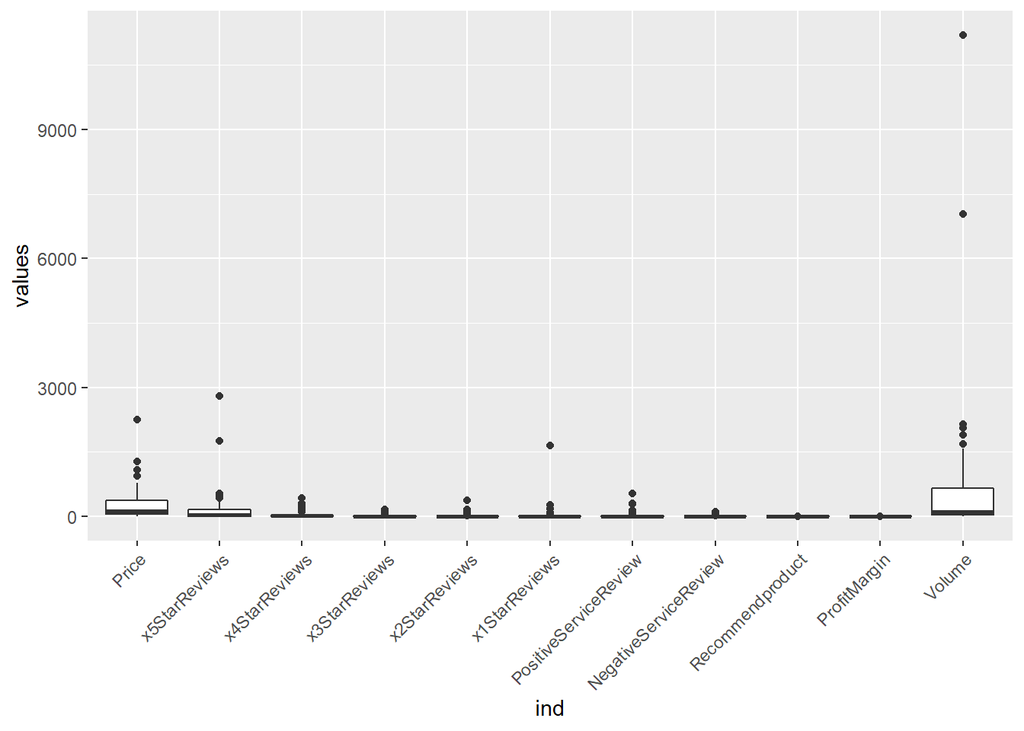

```r
#We find lots of outliers in almost all columns. If we remove them, it will drastically change our dataset (already very small), and so we don't remove all of them.
ggplot(stack(ExistProd), aes(x=ind, y=values)) + geom_boxplot() + theme(axis.text.x = element_text(angle = 45, hjust = 1))
```

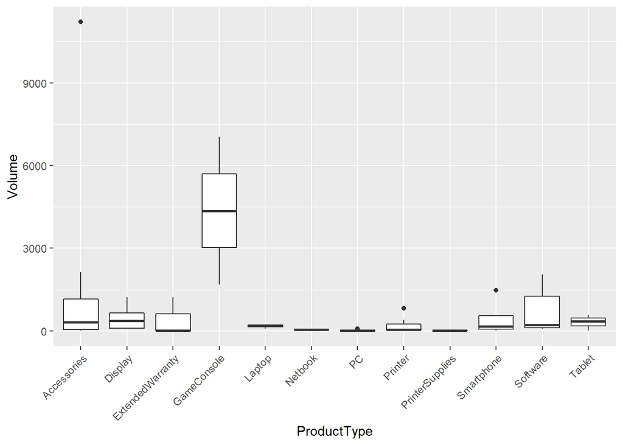

```r
#But we should look more in depth at least in the outliers of the dependent column
ggplot(ExistProd, aes(x=ProductType, y=Volume)) +geom_boxplot() + theme(axis.text.x = element_text(angle = 45, hjust = 1))
```

```r
#We have few outliers here as well. The R Built-in function will tell us the values.
boxplot(ExistProd$Volume, plot = FALSE)$out
```

```
## [1]  2052  2140 11204  1896  7036  1684
```

```r
#But we only want to remove the two extreme outliers because our dataset is small, and because these outliers don't belong to the product types we want to predict.
ExistProd <- ExistProd[-which(ExistProd$Volume > 7000),]
```

## 1.4.Scaling values

```r
#Since different variables have different units, we are going to scale all numeric variables (except label):
for (i in c(2:11)){ExistProd[,i] <- scale(ExistProd[,i])}

#We do the same in NewProd df
for (i in c(2:11)){NewProd[,i] <- scale(NewProd[,i])}
```